# caseStudy1-SIS-phyloseq

miaSim package authors

2023-05-29

#### Package

miaSim 1.6.0

# 1 Introduction

This document provides the detailed code required to replicate case study 1 discussed in Gao *et al.* (2023). Methods in Ecology and Evolution. DOI: 10.1111/2041-210X.14129

For general instructions and examples on using the miaSim package tools, see the [vignette](https://microbiome.github.io/miaSim/articles/miaSim.html). `miaSim` implements tools for microbiome data simulation based on different ecological modeling assumptions. These can be used to simulate species abundance matrices, including time series. For a detailed function documentation, see the [function reference page](https://microbiome.github.io/miaSim/reference/index.html)

# 2 Case study 1: Strongly interacting species (SIS) explaining community types

(Reference: [On the Origins and Control of Community Types in the Human Microbiome](https://journals.plos.org/ploscompbiol/article?id=10.1371/journal.pcbi.1004688))

The aim of this case study is to recalculate this [Figure 2](https://journals.plos.org/ploscompbiol/article?id=10.1371/journal.pcbi.1004688#pcbi-1004688-g002) which demonstrates the occurrence of SIS and the clustering results of communities.

In this figure, from left to right, different power-law distributions (defined by alpha = 7, 3, 2, 1.6, 1.01) controls the strength frequency of inter-species interactions. On the second row, inter-species interactions are visualized in networks. On the third row, the different clustering results in PCoA are demonstrated.

In this case study, we used their same sets of parameters, and acquired the similar results.

## 2.1 Setup

Let us load dependencies

```r
library(ggplot2)
library(igraph)
library(colourvalues)
library(GGally)
library(network)
library(sna)
library(dplyr)
library(philentropy)
library(cluster)
library(ape)
library(intergraph)
library(umap)
library(miaSim)
```

Define a function to generate power-law distribution

```r
rpower <- function(n, alpha, norm = FALSE) {
  u <- runif(n, min = 0, max = 1 - .Machine$double.eps^0.5)
  power <- (1 - u)^(1 / (1 - alpha))
  if (norm) {
    return(power / mean(power))
  } else {
    return(power)
  }
}
```

Load parameters used by Gibson et al.

```r
params <- data.frame(
  alpha = c(7, 3, 2, 1.6, 1.01),
  t_end = c(20, 10, 5, 2, 1),
  t_step = c(0.02, 0.01, 0.005, 0.002, 0.001)
)
set.seed(42)
n_species <- 100
```

Create variables to store results

```r
H <- list()
df <- list()
plot_hist <- list()
N <- list()
interactions_custom <- list()
A <- list()
g <- list()
g_plot <- list()
local_species_pool <- list()
local_A <- list()
```

## 2.2 Generate constants and plot different distributions

```
## [1] "row = 1"
```

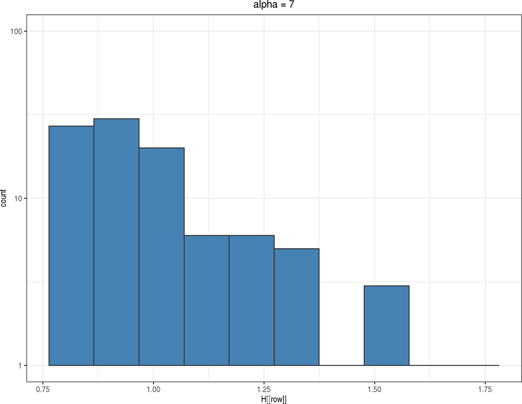

```
## [1] "max edge weight = 0.42198663955657"
```

[figure not shown]

```
## [1] "row = 2"
```

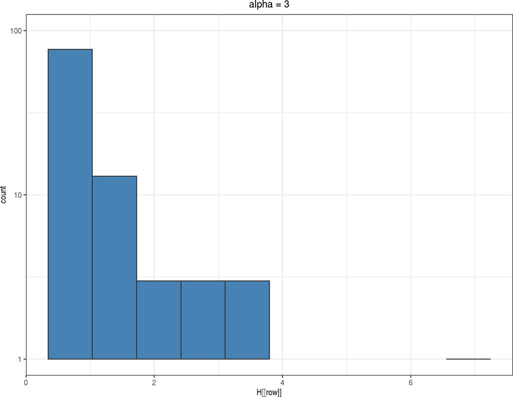

```
## [1] "max edge weight = 1.14350270284621"
```

[figure not shown]

```
## [1] "row = 3"
```

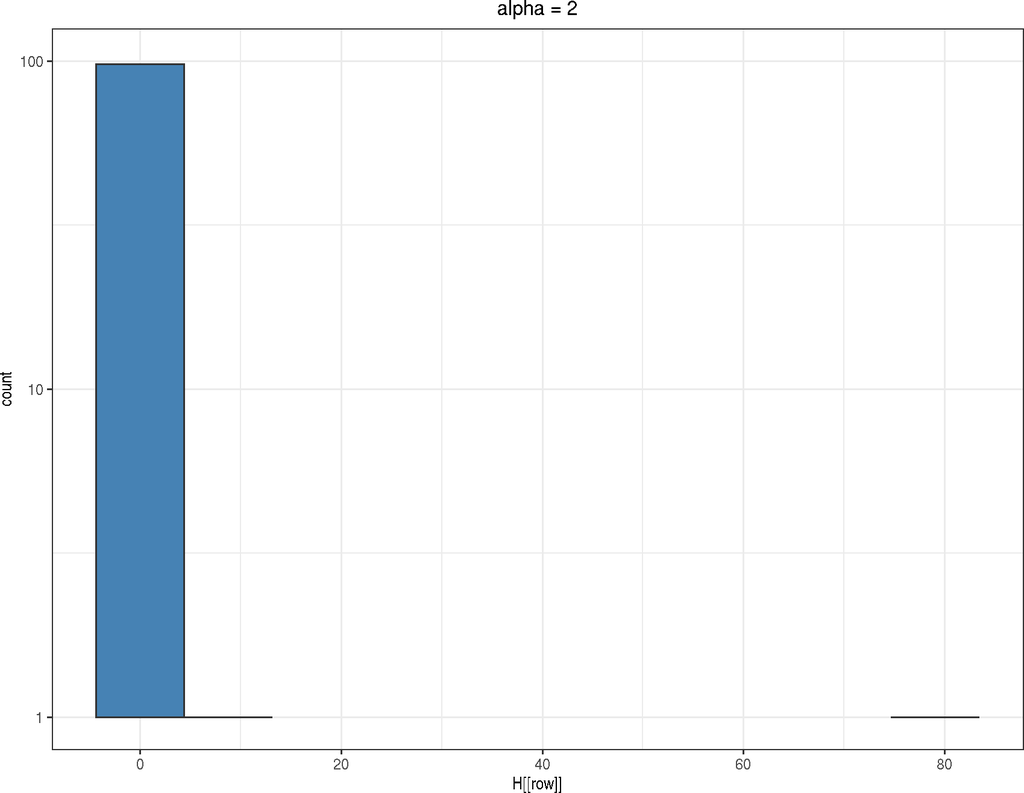

```
## [1] "max edge weight = 12.6240910282149"
```

[figure not shown]

```
## [1] "row = 4"
```

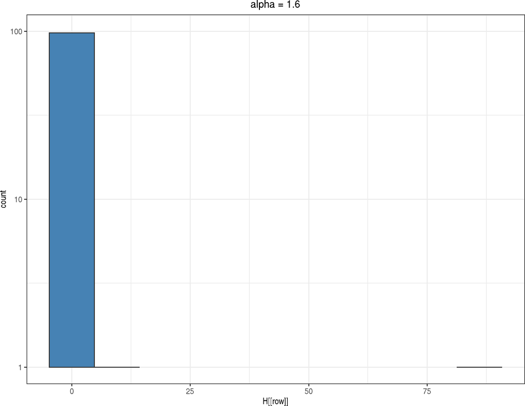

```
## [1] "max edge weight = 11.4025806066921"
```

[figure not shown]

```
## [1] "row = 5"
```

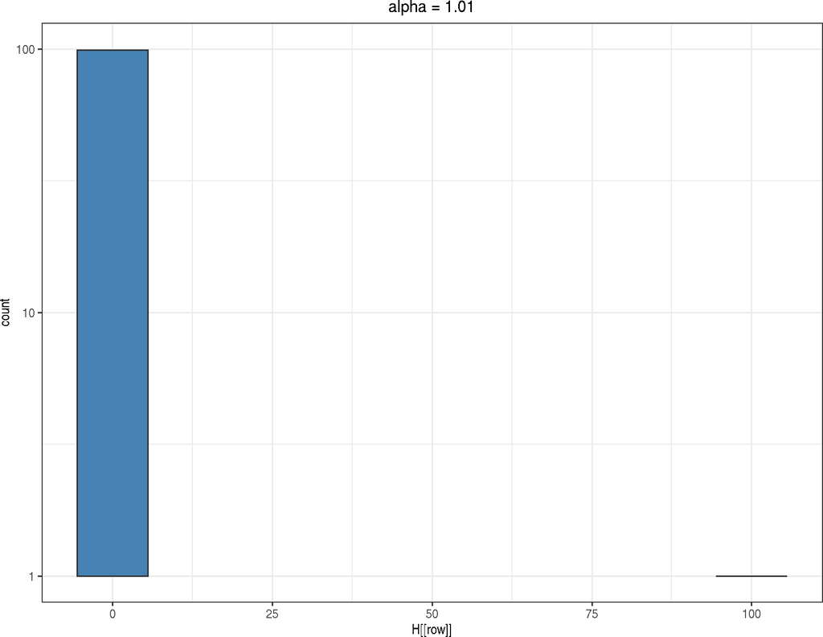

```
## [1] "max edge weight = 19.1461396036079"
```

[figure not shown]

```r
set.seed(42)
for (row in seq_len(nrow(params))) {
  # for each power-law distribution
  print(paste("row =", row))

  H[[ row]] <- rpower(n = n_species, alpha = params$alpha[row], norm = TRUE)
  df[[ row]] <- data.frame(H[[ row]])
  plot_hist[[ row]] <- ggplot(df[[ row]], aes(H[[ row]])) +
    ggtitle(paste("alpha =", params$alpha[[ row]])) +
    geom_histogram(fill = "steelblue", color = "grey20", bins = 10) +
    scale_y_log10(breaks = c(1, 10, 100), limits = c(1, 100)) +
    theme_bw() +
    theme(plot.title = element_text(hjust = 0.5))

  # plot_hist[[ row]]
  print(plot_hist[[ row]])

  N[[ row]] <- matrix(rnorm(n = n_species^2, mean = 0, sd = 1), nrow = n_species)
  diag(N[[ row]]) <- 0
  interactions_custom[[ row]] <- N[[ row]] %*% diag(H[[ row]])
  A[[ row]] <- randomA(
    n_species = 100,
    diagonal = -1,
    scale_off_diagonal = 0.07,
    connectance = 1,
    interactions = interactions_custom[[ row]]
  )
  g[[ row]] <- graph_from_adjacency_matrix(A[[ row]], weighted = TRUE, diag = FALSE)
  print(paste("max edge weight =", max(E(g[[ row]])$weight)))
  rev_viridis <- get_palette("viridis")[rev(seq_len(nrow(get_palette("viridis")))), ]
  E(g[[ row]])$color <- head(colour_values(c(abs(E(g[[ row]])$weight), 0), palette = rev_viridis, alpha = 0, include_alpha = TRUE), -1)
  g_plot[[ row]] <- ggnet2(
    net = g[[ row]],
    mode = "circle",
    node.color = "black",
    node.size = 1,
    edge.color = "color", edge.alpha = 0.25
  ) +
    ggtitle(paste("alpha =", params$alpha[[ row]])) +
    theme(plot.title = element_text(hjust = 0.5))
  # g_plot[[ row]]
  print(g_plot[[ row]])

  local_species_pool[[ row]] <- list()
  local_A[[ row]] <- list()

  for (local_community in seq_len(100)) {
    local_species_pool[[ row]][[local_community]] <- sample(x = 100, size = 80)
    local_A[[ row]][[local_community]] <- A[[ row]][local_species_pool[[ row]][[local_community]], local_species_pool[[ row]][[local_community]]]
  }
  # save histogram and network plots ####
  # ggsave(paste0("hist", params$alpha[row], ".pdf"), plot = plot_hist[[ row]], dpi = 300, width = 6, height = 6, units = "cm")
  # ggsave(paste0("net", params$alpha[row], ".pdf"), plot = g_plot[[ row]], dpi = 300, width = 6, height = 6, units = "cm")
}
```

Identify SIS using H[[ row]]

```r
SIS <- list()
group_sis <- list()
for (row in seq_len(nrow(params))) {
  SIS[[ row]] <- head(order(H[[ row]], decreasing = TRUE), 1)
  group_sis[[ row]] <- list()
  for (local_community in seq_len(100)) {
    if (paste0("sp", SIS[[ row]]) %in% rownames(local_A[[ row]][[local_community]])) {
      group_sis[[ row]][[local_community]] <- "with SIS"
    } else {
      group_sis[[ row]][[local_community]] <- "without SIS"
    }
  }
  group_sis[[ row]] <- unlist(group_sis[[ row]])
}
```

Simulate GLV models using different growth rates in 4 scenarios

The first scenario is the original one from Gibson et al., and the rest are some explorations (the second scenario is assigning various growth rates to random species; the third scenario is assigning faster growth rate to SIS; and the fourth scenario is assigning faster growth rate to non-SIS).

Different scenarios are implemented by overwriting the default random growth rates in simulation function.

Let us prepare result lists and scenarios.

```r
simulation_GLV <- list()
otu_table <- list()
jsd <- list()
PCoA <- list()
PCoA_coord <- list()
bestk <- list()
PAM <- list()
SI <- list()
groups <- list()
pcoa_plot <- list()
dfs_to_bind <- list()

scenarios <- c("original", "various growth rates", "SIS grows faster", "non-SIS grows faster")
growthRates <- vector(mode = "list", length = 4)
growthRates[[1]] <- rep(1, 80)
growthRates[[2]] <- NULL
# growthRates for scenario 3 and 4 are assigned in the following loop

customPalette <- c("#d95319", "#0072bd", "#edb120", "#7e2f8e")
```

In this case study, we only focus on the first scenario. (To explore more, simply remove the first line, then put the code in a for loop like `for (scenario in seq_along(scenarios)) {...}` .)

```r
  scenario <- 1
  print(paste0("scenario: ", scenarios[scenario]))

  ### make new lists ####
  simulation_GLV[[scenario]] <- list()
  otu_table[[scenario]] <- list()
  jsd[[scenario]] <- list()
  PCoA[[scenario]] <- list()
  PCoA_coord[[scenario]] <- list()
  bestk[[scenario]] <- list()
  PAM[[scenario]] <- list()
  SI[[scenario]] <- list()
  groups[[scenario]] <- list()
  pcoa_plot[[scenario]] <- list()

  ### run simulations ####
  for (row in seq_len(nrow(params))) {
    simulation_GLV[[scenario]][[ row]] <- list()
    otu_table[[scenario]][[ row]] <- data.frame(matrix(nrow = 0, ncol = 100))
    colnames(otu_table[[scenario]][[ row]]) <- paste0("sp", 1:100)
    dfs_to_bind[[scenario]] <- list()

    #### overwrite growth rates ####
    for (local_community in seq_len(100)) {
      if (scenario == 3) {
        growthRates[[scenario]] <- 9.9 * local_species_pool[[ row]][[local_community]] == SIS[[ row]] + 0.1
      }
      if (scenario == 4) {
        growthRates[[scenario]] <- -9.9 * local_species_pool[[ row]][[local_community]] == SIS[[ row]] + 10
      }

      simulation_GLV[[scenario]][[ row]][[local_community]] <- simulateGLV(
        n_species = 80,
        names_species = paste0("sp", local_species_pool[[ row]][[local_community]]),
        A = local_A[[ row]][[local_community]],
        x0 = rep(1, 80),
        growth_rates = growthRates[[scenario]],
        t_end = params$t_end[row],
        t_step = params$t_step[row],
        stochastic = FALSE,
        norm = TRUE
      )

      # makePlot(simulation_GLV[[scenario]][[ row]][[local_community]]$matrix)
      dfs_to_bind[[scenario]] <- append(dfs_to_bind[[scenario]], list(simulation_GLV[[scenario]][[ row]][[local_community]]$matrix[time = 1000, ]))
    }

    ### form otu tables ####
    otu_table[[scenario]][[ row]] <- bind_rows(dfs_to_bind[[scenario]])
    otu_table[[scenario]][[ row]] <- otu_table[[scenario]][[ row]][, setdiff(colnames(otu_table[[scenario]][[ row]]), "time")] # Remove time column
    otu_table[[scenario]][[ row]][is.na(otu_table[[scenario]][[ row]])] <- 0

    ### calculate jensen-shannon distance and plot PCoA ####
    jsd[[scenario]][[ row]] <- JSD(as.matrix(otu_table[[scenario]][[ row]]))
    PCoA[[scenario]][[ row]] <- ape::pcoa(as.dist(jsd[[scenario]][[ row]]))
    PCoA_coord[[scenario]][[ row]] <- PCoA[[scenario]][[ row]]$vectors[, 1:2]
    colnames(PCoA_coord[[scenario]][[ row]]) <- c("PCo1", "PCo2")

    bestk[[scenario]][[ row]] <- 2
    PAM[[scenario]][[ row]] <- pam(PCoA[[scenario]][[ row]]$vectors, k = 2)
    SI[[scenario]][[ row]] <- PAM[[scenario]][[ row]]$silinfo$avg.width

    for (k in 3:10) {
      PAMtemp <- pam(PCoA[[scenario]][[ row]]$vectors, k = k)
      if (PAMtemp$silinfo$avg.width > SI[[scenario]][[ row]]) {
        SI[[scenario]][[ row]] <- PAMtemp$silinfo$avg.width
        bestk[[scenario]][[ row]] <- k
        PAM[[scenario]][[ row]] <- PAMtemp
      }
    }

    groups[[scenario]][[ row]] <- factor(PAM[[scenario]][[ row]]$clustering)

    dataframe_pcoa <- as.data.frame(PCoA_coord[[scenario]][[ row]])
    dataframe_pcoa$group <- groups[[scenario]][[ row]]
    pcoa_plot[[scenario]][[ row]] <- ggplot(
      dataframe_pcoa,
      aes(x = PCo1, y = PCo2, color = group)
    ) +
      ggtitle(paste("scenario", scenario, scenarios[scenario], ";", "alpha =", params$alpha[[ row]])) +
      geom_point() +
      # coord_fixed(xlim = c(-1, 1), ylim = c(-1, 1)) +
      theme_bw() +
      scale_color_manual(values = customPalette) +
      theme(legend.position = "none", plot.title = element_text(hjust = 0.5))
    print(pcoa_plot[[scenario]][[ row]])
  }
```

[output not shown]

Validate relationship between cluster and SIS

```r
pcoa_plot_sis <- list()
for (row in seq_len(nrow(params))) {
  pcoa_plot_sis[[ row]] <- ggplot(as.data.frame(PCoA_coord[[1]][[ row]]), aes(x = PCo1, y = PCo2)) +
    geom_point(aes(color = group_sis[[ row]])) +
    ggtitle(paste("alpha =", params$alpha[[ row]])) +
    theme_bw() +
    theme(plot.title = element_text(hjust = 0.5))
  print(pcoa_plot_sis[[ row]])

  # ggsave(paste0("pcoa_validation_", params$alpha[row], ".pdf"), plot = pcoa_plot_sis[[ row]], dpi = 300, width = 6, height = 6, units = "cm")
}
```

[output not shown]